# MEGENA pipeline

Won-Min Song

March 10, 2022

## MEGENA pipeline as of 02/20/2020

This is a routine MEGENA pipeline description encompassing from data correlation analysis to module plotting, and is based on version 1.3.6 [https://CRAN.R-project.org/package=MEGENA](https://cran.r-project.org/package=MEGENA).Please cite the paper below when MEGENA is applied as part of your analysis:

Song W.-M., Zhang B. (2015) Multiscale Embedded Gene Co-expression Network Analysis. PLoS Comput Biol 11(11): e1004574. doi: 10.1371/journal.pcbi.1004574.

For statistical mechanics aspects involved in MEGENA, please check:

Song W.-M., Di Matteo T.and Aste T., Building Complex Networks with Platonic Solids, Physical Reivew E, 2012 Apr;85(4 Pt 2):046115.

# calculate correlation

```r
rm(list = ls()) # rm R working space

library(MEGENA)
```

```r
# input parameters
n.cores <- 2; # number of cores/threads to call for PCP
doPar <-TRUE; # do we want to parallelize?
method = "pearson" # method for correlation. either pearson or spearman.
FDR.cutoff = 0.05 # FDR threshold to define significant correlations upon shuffling samples.
module.pval = 0.05 # module significance p-value. Recommended is 0.05.
hub.pval = 0.05 # connectivity significance p-value based random tetrahedral networks
cor.perm = 10; # number of permutations for calculating FDRs for all correlation pairs.
hub.perm = 100; # number of permutations for calculating connectivity significance p-value.

# annotation to be done on the downstream
annot.table=NULL
id.col = 1
symbol.col= 2
###########

data(Sample_Expression) # load toy example data

rho.out = calculate.rho.signed(datExpr,n.perm = 10,FDR.cutoff = FDR.cutoff,estimator = method,
                               use.obs = "na.or.complete",
                               direction = "absolute",
                               rho.thresh = NULL,sort.el = TRUE)
```

```
## i = 1
## i = 2
## i = 3
## i = 4
## i = 5
## i = 6
## i = 7
## i = 8
## i = 9
## i = 10
```

# calculate PFN

In this step, Planar Filtered Network (PFN) is calculated by taking significant correlation pairs, ijw. In the case of utilizing a different similarity measure, one can independently format the results into 3-column data frame with column names c("row","col","weight"), and make sure the weight column ranges within 0 to 1. Using this as an input to calculate.PFN() will work just as fine.

```r
#### register multiple cores if needed: note that set.parallel.backend() is deprecated.
run.par = doPar & (getDoParWorkers() == 1)
if (run.par)
{
  cl <- parallel::makeCluster(n.cores)
  registerDoParallel(cl)
  # check how many workers are there
  cat(paste("number of cores to use:",getDoParWorkers(),"\n",sep = ""))
}
```

```
## number of cores to use:2
```

```r
##### calculate PFN
el <- calculate.PFN(rho.out$signif.ijw,doPar = doPar,num.cores = n.cores,keep.track = FALSE)
```

```
## ####### PFN Calculation commences ########
## [1] "343 out of 894 has been included."
## [1] "471 out of 894 has been included."
## [1] "556 out of 894 has been included."
## [1] "Performing parallel quality checks on 2000"
## [1] "Qualified edges: 249"
## [1] "663 out of 894 has been included."
## [1] "710 out of 894 has been included."
## [1] "Performing parallel quality checks on 2000"
## [1] "Qualified edges: 78"
## [1] "759 out of 894 has been included."
## [1] "Performing parallel quality checks on 2000"
## [1] "Qualified edges: 60"
## [1] "802 out of 894 has been included."
## [1] "Performing parallel quality checks on 2000"
```

[output cut: 51 more lines]

```r
g <- graph.data.frame(el,directed = FALSE)
```

# perform clustering

MCA clustering is performed to identify multiscale clustering analysis. "MEGENA.output"" is the core output to be used in the down-stream analyses for summarization and plotting.

```r
##### perform MCA clustering.
MEGENA.output <- do.MEGENA(g,
 mod.pval = module.pval,hub.pval = hub.pval,remove.unsig = TRUE,
 min.size = 10,max.size = vcount(g)/2,
 doPar = doPar,num.cores = n.cores,n.perm = hub.perm,
 save.output = FALSE)

###### unregister cores as these are not needed anymore.
if (getDoParWorkers() > 1)
{
  env <- foreach:::.foreachGlobals
  rm(list=ls(name=env), pos=env)
}
```

# summarize results

```r
summary.output <- MEGENA.ModuleSummary(MEGENA.output,
    mod.pvalue = module.pval,hub.pvalue = hub.pval,
    min.size = 10,max.size = vcount(g)/2,
    annot.table = annot.table,id.col = id.col,symbol.col = symbol.col,
    output.sig = TRUE)
```

```r
if (!is.null(annot.table))
{
  # update annotation to map to gene symbols
  V(g)$name <- paste(annot.table[[symbol.col]][match(V(g)$name,annot.table[[id.col]])],V(g)$name,sep = "|")
  summary.output <- output[c("mapped.modules","module.table")]
  names(summary.output)[1] <- "modules"
}

print(head(summary.output$modules,2))
```

```
## $c1_2
##   [1] "C1QB"         "C1QA"         "SASH3"        "HLA-DPA1"     "PLEK"
##   [6] "NCKAP1L"      "EVI2B"        "HLA-DRA"      "FCGR1A"       "CD53"
##  [11] "PTPRC"        "DOCK2"        "ITGB2"        "FCGR1C"       "ARHGAP9"
##  [16] "CD37"         "CD4"          "PTPN7"        "HLA-DMB"      "CD48"
##  [21] "FYB"          "CYBB"         "IKZF1"        "LILRB2"       "HLA-DQA1"
##  [26] "LILRB4"       "IL10RA"       "CCR5"         "HLA-DPB1"     "LILRB1"
##  [31] "CORO1A"       "SPN"          "PSTPIP1"      "SNX20"        "MNDA"
##  [36] "TFEC"         "FGL2"         "CD74"         "C1QC"         "ITGAX"
##  [41] "FERMT3"       "CCR1"         "PRKCB"        "CD1E"         "HLA-DQB1"
##  [46] "IL12RB1"      "NCF1C"        "CLEC10A"      "FPR3"         "WDFY4"
##  [51] "SP140"        "FCGR3A"       "CTSS"         "BIN2"         "SIGLEC7"
##  [56] "TLR8"         "HLA-DRB1"     "IFI30"        "GPR183"       "NCF2"
##  [61] "TMC8"         "MRC1"         "GIMAP5"       "CLEC17A"      "CD86"
##  [66] "PIK3AP1"      "CSF1R"        "CD163"        "P2RY13"       "DOK2"
```

[output cut: 36 more lines]

```r
print(summary.output$module.table)
```

```
##       module.id module.size module.parent
## c1_2       c1_2         133          c1_1
## c1_3       c1_3         121          c1_1
## c1_4       c1_4          22          c1_1
## c1_5       c1_5          24          c1_1
## c1_6       c1_6          26          c1_2
## c1_7       c1_7          68          c1_2
## c1_10     c1_10          65          c1_3
## c1_12     c1_12          25          c1_3
## c1_13     c1_13          11          c1_3
## c1_15     c1_15          16          c1_4
## c1_19     c1_19          22          c1_7
## c1_21     c1_21          56         c1_10
## c1_23     c1_23          11         c1_12
##                                                                  module.hub
## c1_2  SASH3(34),CD53(33),PTPRC(26),CD86(20),NCKAP1L(19),FERMT3(19),PLEK(18)
## c1_3                           CD2(33),CD3E(32),GBP5(20),ITK(19),SLAMF6(18)
## c1_4                                                              MS4A1(12)
## c1_5                                                              IFIT3(19)
## c1_6                                                               CD86(14)
## c1_7                        CD53(32),SASH3(27),PLEK(17),NCKAP1L(17),CD4(16)
## c1_10                                                      CD2(32),CD3E(29)
## c1_12                                                            SLAMF6(14)
## c1_13                                                              PSMB9(9)
## c1_15                                                   MS4A1(12),FCRL1(11)
## c1_19                                                   SASH3(19),PTPN7(12)
## c1_21                                                      CD2(32),CD3E(29)
## c1_23                                                            SLAMF6(10)
##       module.scale module.pvalue
## c1_2            S4          0.00
## c1_3          <NA>          0.00
## c1_4            S4          0.00
## c1_5            S4          0.00
## c1_6            S3          0.02
## c1_7          <NA>          0.00
## c1_10         <NA>          0.00
## c1_12           S4          0.00
## c1_13           S4          0.00
## c1_15           S3          0.03
## c1_19           S3          0.01
## c1_21           S4          0.00
## c1_23           S3          0.00
```

# Plot some modules

You can generate refined module network plots:

```r
library(ggplot2)
library(ggraph)
pnet.obj <- plot_module(output.summary = summary.output,PFN = g,subset.module = "c1_3",
    layout = "kamada.kawai",label.hubs.only = TRUE,
    gene.set = NULL,color.code =  "grey",
    output.plot = FALSE,out.dir = "modulePlot",col.names = c("magenta","green","cyan"),label.scaleFactor = 20,
    hubLabel.col = "black",hubLabel.sizeProp = 1,show.topn.hubs = Inf,show.legend = TRUE)
```

```
## Processing module:c1_3
##  - # of genes: 121
##  - # of hubs: 5
## - generating module subnetwork figure...
```

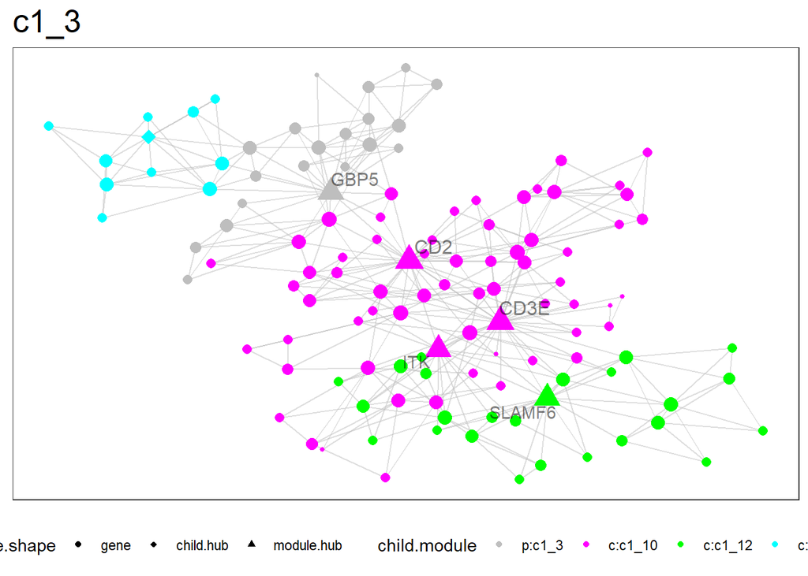

```r
#X11();
print(pnet.obj[[1]])
```

# plot module hierarchy

You can generate module hierarchy plot in many ways to accommodate for various needs.

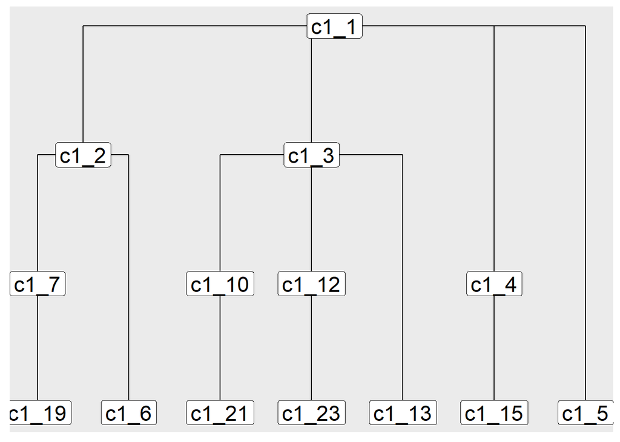

```r
module.table <- summary.output$module.table
htbl = module.table[,c("module.parent","module.id")]

### hierarchy plot with labels
hplot = get_module_hierarchy_graph(htbl,max.depth = 5,anchor.mid = NULL,h.scale = NULL,is.circular = FALSE,layout = "dendrogram",add_names = TRUE)
print(hplot$pobj)
```

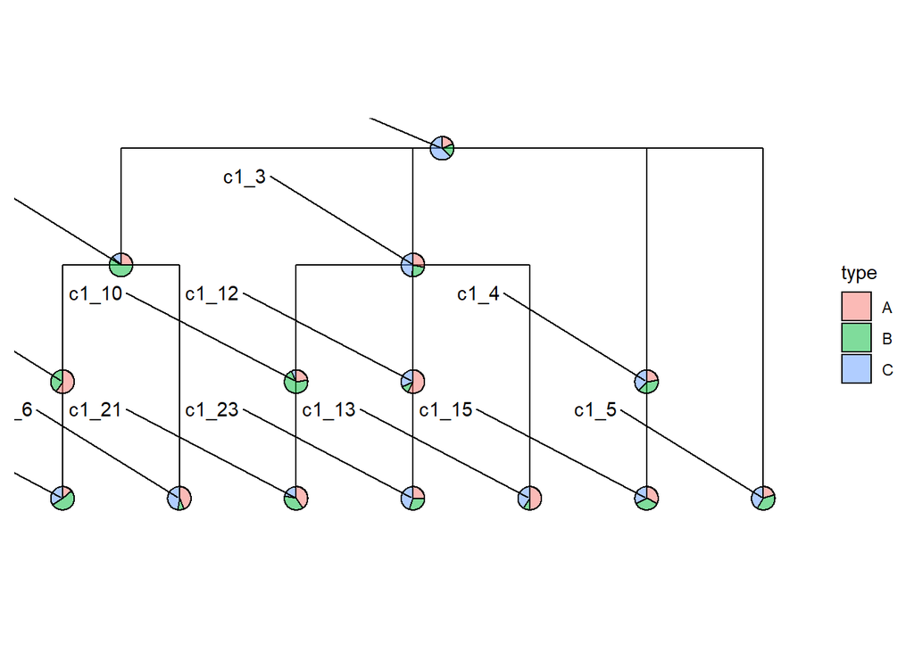

```r
### hierarchy plot with piechart to represent multiple attributes of module
hplot = get_module_hierarchy_graph(htbl,max.depth = 5,anchor.mid = NULL,h.scale = NULL,is.circular = FALSE,layout = "dendrogram",add_names = FALSE)

# get a mock piechart matrix
pie.data = matrix(runif(nrow(hplot$pobj$data)*3,0,1),nrow = nrow(hplot$pobj$data))
colnames(pie.data) = LETTERS[1:ncol(pie.data)]

# update with pie charts
library(scatterpie)
pie.dat = data.frame(x = hplot$pobj$data$x,y = hplot$pobj$data$y,as.data.frame(pie.data))

pobj.pie = hplot$pobj + geom_scatterpie(data=pie.dat,aes(x=x, y=y,r = 0.1),
                                cols=colnames(pie.data),alpha = 0.5) + coord_equal() +
    theme_bw() + theme(axis.line = element_blank(),axis.ticks = element_blank(),
                       axis.title = element_blank(),axis.text = element_blank(),
                       panel.grid.major = element_blank(),panel.grid.minor = element_blank(),
                       panel.border = element_blank())

# update module names
library(ggrepel)
pobj.pie = pobj.pie + geom_text_repel(data = pobj.pie$data,aes(x = x,y = y,label = name),vjust = -2.5)
print(pobj.pie)
```

# Plot module characteristics with sunburst plot

Another alternative is to plot sunbursts reflecting MEGENA hierarchy.

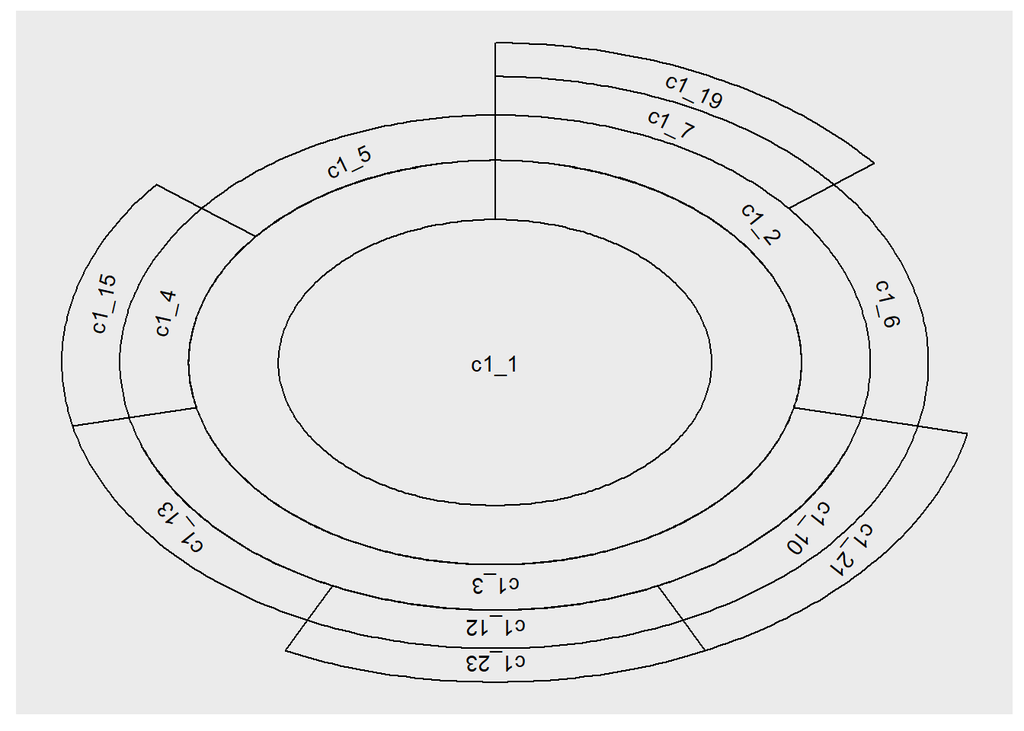

```r
# no coloring
sbobj1 = draw_sunburst_wt_fill(module.df = summary.output$module.table,
  feat.col = NULL,id.col = "module.id",parent.col = "module.parent")
print(sbobj1)
```

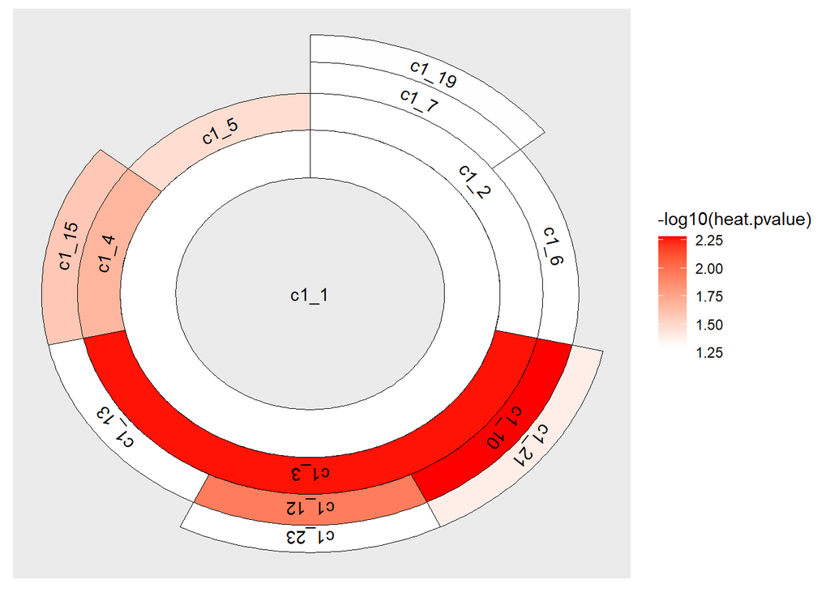

```r
# get some coloring (with log transform option)
mdf= summary.output$module.table
mdf$heat.pvalue = runif(nrow(mdf),0,0.1)

sbobj2 = draw_sunburst_wt_fill(module.df = mdf,feat.col = "heat.pvalue",log.transform = TRUE,
  fill.type = "continuous",
  fill.scale = scale_fill_gradient2(low = "white",mid = "white",high = "red",
  midpoint = -log10(0.05),na.value = "white"),
  id.col = "module.id",parent.col = "module.parent")
print(sbobj2)
```

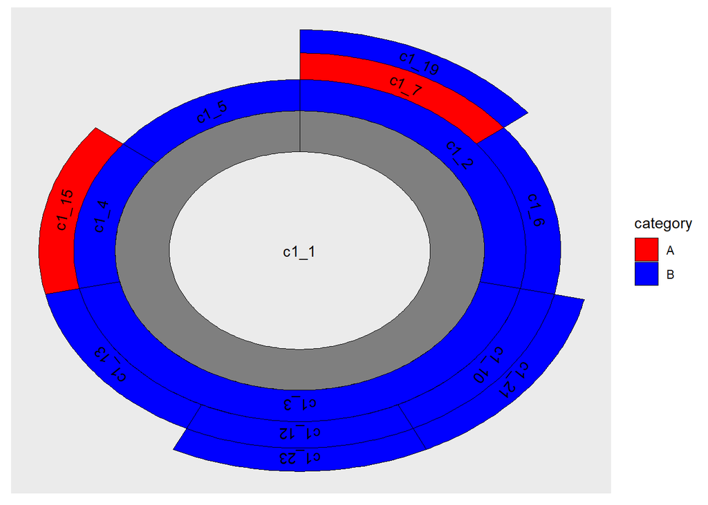

```r
# get discrete coloring done
mdf$category = factor(sample(x = c("A","B"),size = nrow(mdf),replace = TRUE))
sbobj3 = draw_sunburst_wt_fill(module.df = mdf,feat.col = "category",
  fill.type = "discrete",
  fill.scale = scale_fill_manual(values = c("A" = "red","B" = "blue")),
  id.col = "module.id",parent.col = "module.parent")
print(sbobj3)
```

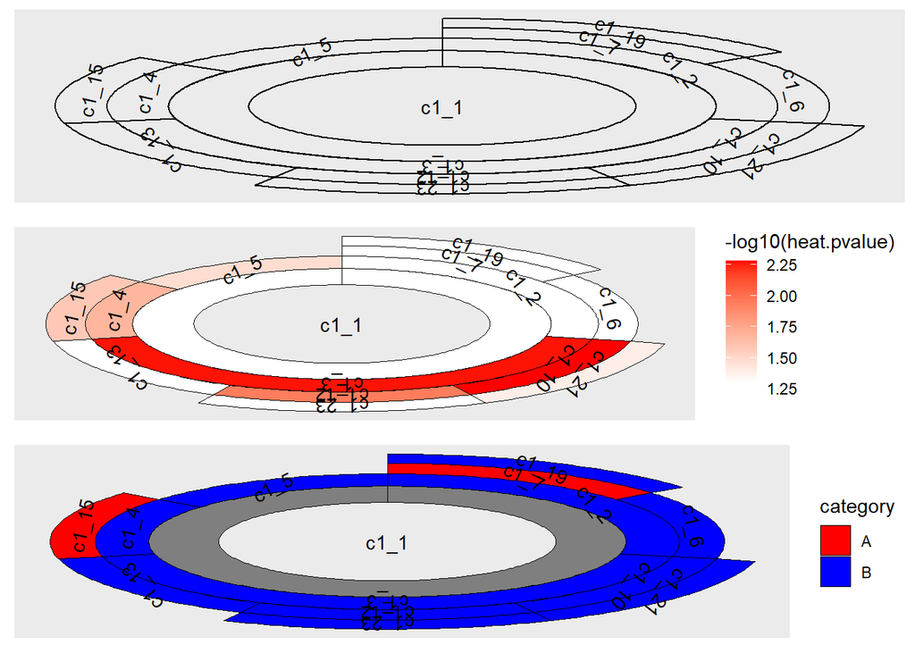

```r
## Now, use viewport function to organize sunbursts in an array.
library(grid)
# organize plots into a list
plotlist = list(sbobj1,sbobj2,sbobj3)

# create grid of subplots
grid.newpage()
pushViewport(viewport(layout = grid.layout(3,1)))

for (i in 1:length(plotlist))
{
  print(plotlist[[i]], vp = viewport(layout.pos.col = 1,layout.pos.row = i))
}
```